# RD modelling - simulations

Doranne Thomassen

03/22/2021

# Single trial

## Binary treatment variable + binary covariate

```r
set.seed(456)
n_arm <- 50
treat <- c(rep(0,n_arm), rep(1,n_arm))
cat("", file = "modelstats_bin.html", append = FALSE)

beta_xlim = c(0,0.6)
beta_ylim = c(0,20)

#beta1=beta2=0.3, increase alpha
#alpha = 0.2
x <- c(rbinom(n=n_arm, size=1, prob = 0.5), rbinom(n=n_arm, size=1, prob = 0.5))
true.beta <- 0.3
true.p <- 0.2+true.beta*treat+0.3*x
xpred <- c(0,1)
TEfun <- function(x){
  return(true.beta)
}

cure <- rbinom(n=length(treat), size=1, prob = true.p)
trial.dat <- data.frame(cure, treat, x)


plots <- run.sim(true.beta=true.beta,
        trial.dat = trial.dat,
        filename="2x_bin_p=0.2+0.3x+0.3x",
        title=expression(paste(x[i*1], " binary, ", x[i*2], " binary, ", p[i],"=0.2+0.3",x[i*1],"+0.3",x[i*2],".")),
        true.p = true.p,
        true.TE.fun=TEfun,
        xpred = xpred)

beta.plot <- plots$beta.frame
plots$kable_modstats
```

1. Proposed model
3. Logistic model + transform
2. Model by Warn et al.

MLE binomial GLM id-link

MLE binomial GLM logit-link

OLS estimate

Brier.mean

0.2002

0.1998

0.2003

0.2002

0.1999

0.2000

Brier.median

0.2002

0.1998

0.2004

0.2002

0.1999

0.2000

RMSE.p.mean

0.0667

0.0697

0.0682

0.0710

0.0708

0.0708

RMSE.p.median

0.0668

0.0708

0.0690

0.0710

0.0708

0.0708

MAE.p.mean

0.0550

0.0512

0.0562

0.0546

0.0516

0.0520

MAE.p.median

0.0529

0.0526

0.0550

0.0546

0.0516

0.0520

IC

122.5936

123.3860

123.0564

123.2907

123.3334

NA

Rhat_Conv

1.0006

1.0017

1.0005

-1.0000

-1.0000

-1.0000

RunTimes

1.5946

1.7661

1.3854

0.0045

0.0012

0.0010

ESSp0

2000.0000

1900.0000

900.0000

0.0000

0.0000

0.0000

ESSp1

2000.0000

1100.0000

2000.0000

0.0000

0.0000

0.0000

```r
rm(cure, trial.dat, true.beta, true.p, x, xpred)

#alpha = 0.3
x <- c(rbinom(n=n_arm, size=1, prob = 0.5), rbinom(n=n_arm, size=1, prob = 0.5))
true.beta <- 0.3
true.p <- 0.3+true.beta*treat+0.3*x
xpred <- c(0,1)
TEfun <- function(x){
  return(true.beta)
}

cure <- rbinom(n=length(treat), size=1, prob = true.p)
trial.dat <- data.frame(cure, treat, x)


plots <- run.sim(true.beta=true.beta,
        trial.dat = trial.dat,
        filename="2x_bin_p=0.3+0.3x+0.3x",
        title=expression(paste(x[i*1], " binary, ", x[i*2], " binary, ", p[i],"=0.3+0.3",x[i*1],"+0.3",x[i*2],".")),
        true.p = true.p,
        true.TE.fun=TEfun,
        xpred = xpred,
        beta_xlim = c(0,0.6),
        beta_ylim = c(0,20))

beta.plot <- rbind(beta.plot, plots$beta.frame)
plots$kable_modstats
```

1. Proposed model
3. Logistic model + transform
2. Model by Warn et al.

MLE binomial GLM id-link

MLE binomial GLM logit-link

OLS estimate

Brier.mean

0.1515

0.1501

0.1516

0.1511

0.1501

0.1509

Brier.median

0.1512

0.1501

0.1514

0.1511

0.1501

0.1509

RMSE.p.mean

0.0615

0.0807

0.0616

0.0746

0.0812

0.0734

RMSE.p.median

0.0648

0.0848

0.0643

0.0746

0.0812

0.0734

MAE.p.mean

0.0494

0.0587

0.0501

0.0620

0.0590

0.0612

MAE.p.median

0.0525

0.0622

0.0530

0.0620

0.0590

0.0612

IC

98.3526

98.0026

98.5604

98.6612

98.2272

NA

Rhat_Conv

1.0016

1.0005

1.0011

-1.0000

-1.0000

-1.0000

RunTimes

1.4964

1.8135

1.4307

0.0016

0.0021

0.0048

ESSp0

1300.0000

2000.0000

2000.0000

0.0000

0.0000

0.0000

ESSp1

1300.0000

2000.0000

2000.0000

0.0000

0.0000

0.0000

```r
rm(cure, trial.dat, true.beta, true.p, x, xpred)


#alpha = 0.39
x <- c(rbinom(n=n_arm, size=1, prob = 0.5), rbinom(n=n_arm, size=1, prob = 0.5))
true.beta <- 0.3
true.p <- 0.39+true.beta*treat+0.3*x
xpred <- c(0,1)
TEfun <- function(x){
  return(true.beta)
}

cure <- rbinom(n=length(treat), size=1, prob = true.p)
trial.dat <- data.frame(cure, treat, x)


plots <- run.sim(true.beta=true.beta,
        trial.dat = trial.dat,
        filename="2x_bin_p=0.39+0.3x+0.3x",
        title=expression(paste(x[i*1], " binary, ", x[i*2], " binary, ", p[i],"=0.39+0.3",x[i*1],"+0.3",x[i*2],".")),
        true.p = true.p,
        true.TE.fun=TEfun,
        xpred = xpred,
        beta_xlim = c(0,0.6),
        beta_ylim = c(0,20))

beta.plot <- rbind(beta.plot, plots$beta.frame)
plots$kable_modstats
```

1. Proposed model
3. Logistic model + transform
2. Model by Warn et al.

MLE binomial GLM id-link

MLE binomial GLM logit-link

OLS estimate

Brier.mean

0.2020

0.2050

0.2030

0.2032

0.2049

0.2019

Brier.median

0.2017

0.2050

0.2029

0.2032

0.2049

0.2019

RMSE.p.mean

0.0625

0.0665

0.0489

0.0511

0.0661

0.0609

RMSE.p.median

0.0603

0.0639

0.0466

0.0511

0.0661

0.0609

MAE.p.mean

0.0501

0.0570

0.0398

0.0416

0.0574

0.0470

MAE.p.median

0.0478

0.0561

0.0358

0.0416

0.0574

0.0470

IC

121.2124

123.8466

120.8932

120.1456

123.6325

NA

Rhat_Conv

1.0010

1.0013

1.0007

-1.0000

-1.0000

-1.0000

RunTimes

1.4668

1.8044

1.5315

0.0028

0.0013

0.0007

ESSp0

2000.0000

2000.0000

2000.0000

0.0000

0.0000

0.0000

ESSp1

2000.0000

2000.0000

2000.0000

0.0000

0.0000

0.0000

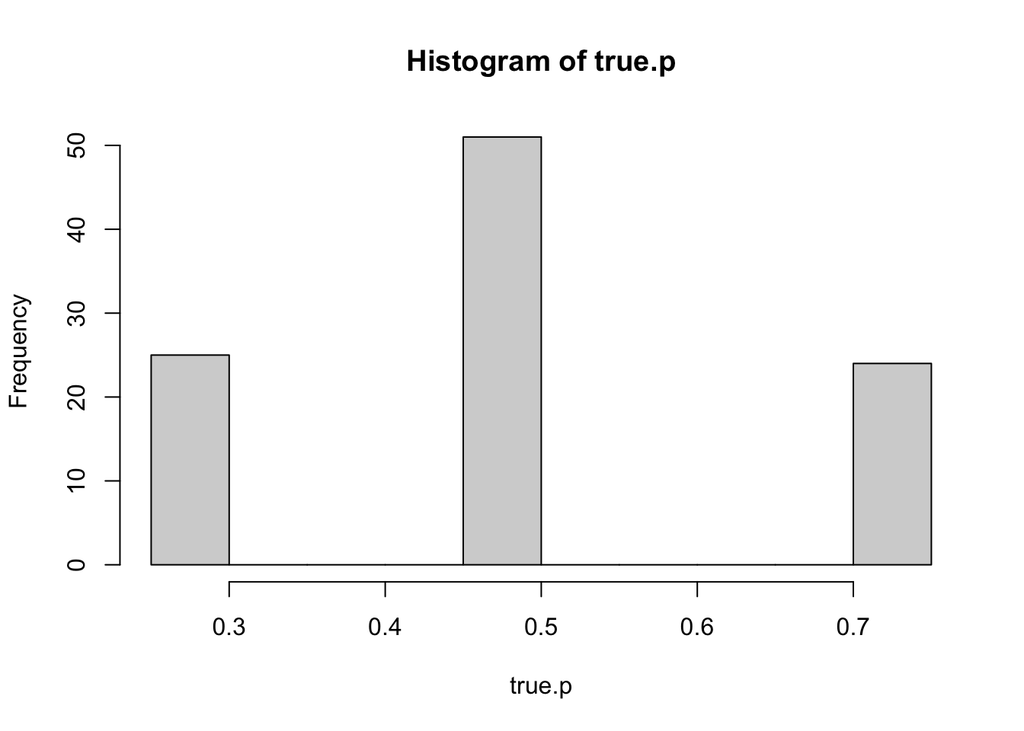

```r
rm(cure, trial.dat, true.beta, true.p, x, xpred)


#alpha=-1
x <- c(rbinom(n=n_arm, size=1, prob = 0.5), rbinom(n=n_arm, size=1, prob = 0.5))
true.beta <- NA
true.p <- expit(-1+1*treat+x)
hist(true.p)
```

```r
xpred <- c(0,1)
TEfun <- function(x){
  TE <- expit(-1+1+x)-expit(-1+0+x)
  return(TE)
}

cure <- rbinom(n=length(treat), size=1, prob = true.p)
trial.dat <- data.frame(cure, treat, x)

plots <- run.sim(true.beta=true.beta,
        trial.dat = trial.dat,
        filename="2x_bin_p=expit(-1+x+x)",
        title=expression(paste(x[i*1], " binary, ", x[i*2], " binary, ", p[i],"=expit(-1+",x[i*1],"+",x[i*2],")")),
        true.p = true.p,
        true.TE.fun=TEfun,
        xpred = xpred,
        beta_xlim = c(0,0.6),
        beta_ylim = c(0,20))

beta.plot <- rbind(beta.plot, plots$beta.frame)
plots$kable_modstats
```

1. Proposed model
3. Logistic model + transform
2. Model by Warn et al.

MLE binomial GLM id-link

MLE binomial GLM logit-link

OLS estimate

Brier.mean

0.2208

0.2190

0.2208

0.2205

0.2190

0.2204

Brier.median

0.2208

0.2189

0.2207

0.2205

0.2190

0.2204

RMSE.p.mean

0.0779

0.0855

0.0781

0.0797

0.0858

0.0853

RMSE.p.median

0.0779

0.0871

0.0789

0.0797

0.0858

0.0853

MAE.p.mean

0.0707

0.0817

0.0707

0.0745

0.0823

0.0823

MAE.p.median

0.0717

0.0835

0.0723

0.0745

0.0823

0.0823

IC

132.2289

132.5045

132.4298

132.7473

132.1805

NA

Rhat_Conv

1.0006

1.0008

1.0025

-1.0000

-1.0000

-1.0000

RunTimes

1.4089

1.9055

1.5023

0.0016

0.0019

0.0012

ESSp0

2000.0000

2000.0000

2000.0000

0.0000

0.0000

0.0000

ESSp1

2000.0000

2000.0000

730.0000

0.0000

0.0000

0.0000

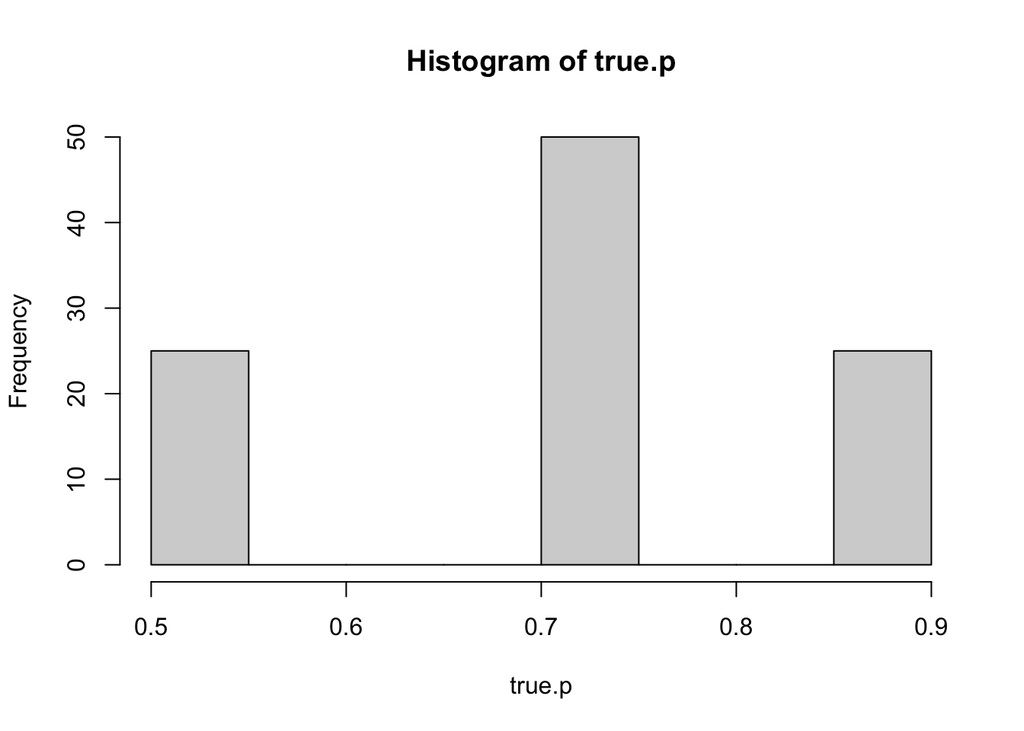

```r
rm(cure, trial.dat, true.beta, true.p, x, xpred)

#alpha=0
x <- c(rbinom(n=n_arm, size=1, prob = 0.5), rbinom(n=n_arm, size=1, prob = 0.5))
true.beta <- NA
true.p <- expit(0+1*treat+x)
hist(true.p)
```

```r
xpred <- c(0,1)
TEfun <- function(x){
  TE <- expit(0+1+x)-expit(0+0+x)
  return(TE)
}

cure <- rbinom(n=length(treat), size=1, prob = true.p)
trial.dat <- data.frame(cure, treat, x)

plots <- run.sim(true.beta=true.beta,
        trial.dat = trial.dat,
        filename="2x_bin_p=expit(0+x+x)",
        title=expression(paste(x[i*1], " binary, ", x[i*2], " binary, ", p[i],"=expit(0+",x[i*1],"+",x[i*2],")")),
        true.p = true.p,
        true.TE.fun=TEfun,
        xpred = xpred,
        beta_xlim = c(0,0.6),
        beta_ylim = c(0,20))

beta.plot <- rbind(beta.plot, plots$beta.frame)
plots$kable_modstats
```

1. Proposed model
3. Logistic model + transform
2. Model by Warn et al.

MLE binomial GLM id-link

MLE binomial GLM logit-link

OLS estimate

Brier.mean

0.2143

0.2147

0.2141

0.2143

0.2146

0.2140

Brier.median

0.2143

0.2147

0.2140

0.2143

0.2146

0.2140

RMSE.p.mean

0.0849

0.0912

0.0873

0.0787

0.0925

0.0931

RMSE.p.median

0.0832

0.0891

0.0855

0.0787

0.0925

0.0931

MAE.p.mean

0.0675

0.0737

0.0689

0.0588

0.0752

0.0752

MAE.p.median

0.0655

0.0742

0.0665

0.0588

0.0752

0.0752

IC

128.6503

129.4117

128.7090

129.0881

129.5143

NA

Rhat_Conv

1.0005

1.0005

1.0019

-1.0000

-1.0000

-1.0000

RunTimes

1.5416

1.7843

1.4640

0.0015

0.0012

0.0007

ESSp0

2000.0000

2000.0000

2000.0000

0.0000

0.0000

0.0000

ESSp1

2000.0000

2000.0000

1100.0000

0.0000

0.0000

0.0000

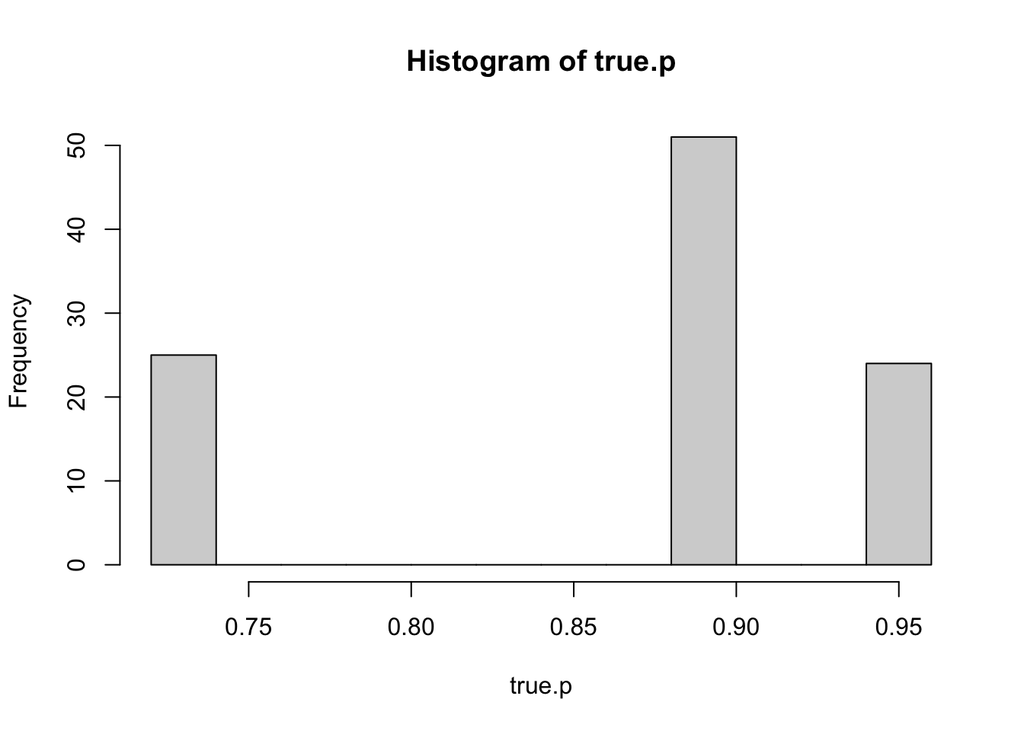

```r
rm(cure, trial.dat, true.beta, true.p, x, xpred)

#alpha=1
x <- c(rbinom(n=n_arm, size=1, prob = 0.5), rbinom(n=n_arm, size=1, prob = 0.5))
true.beta <- NA
true.p <- expit(1+1*treat+x)
hist(true.p)
```

```r
xpred <- c(0,1)
TEfun <- function(x){
  TE <- expit(1+1+x)-expit(1+0+x)
  return(TE)
}

cure <- rbinom(n=length(treat), size=1, prob = true.p)
trial.dat <- data.frame(cure, treat, x)

plots <- run.sim(true.beta=true.beta,
        trial.dat = trial.dat,
        filename="2x_bin_p=expit(1+x+x)",
        title=expression(paste(x[i*1], " binary, ", x[i*2], " binary, ", p[i],"=expit(1+",x[i*1],"+",x[i*2],")")),
        true.p = true.p,
        true.TE.fun=TEfun,
        xpred = xpred,
        beta_xlim = c(0,0.6),
        beta_ylim = c(0,20))

beta.plot <- rbind(beta.plot, plots$beta.frame)
plots$kable_modstats
```

1. Proposed model
3. Logistic model + transform
2. Model by Warn et al.

MLE binomial GLM id-link

MLE binomial GLM logit-link

OLS estimate

Brier.mean

0.0694

0.0681

0.0688

NA

0.0681

0.0685

Brier.median

0.0691

0.0682

0.0685

NA

0.0681

0.0685

RMSE.p.mean

0.0486

0.0624

0.0395

NA

0.0621

0.0643

RMSE.p.median

0.0520

0.0707

0.0453

NA

0.0621

0.0643

MAE.p.mean

0.0361

0.0598

0.0373

NA

0.0594

0.0594

MAE.p.median

0.0397

0.0680

0.0429

NA

0.0594

0.0594

IC

55.5285

54.0080

53.0392

0e+00

54.0466

NA

Rhat_Conv

1.0006

1.0005

1.0033

0e+00

-1.0000

-1.0000

RunTimes

1.3786

1.7687

1.3767

9e-04

0.0012

0.0007

ESSp0

2000.0000

1600.0000

2000.0000

0e+00

0.0000

0.0000

ESSp1

2000.0000

2000.0000

650.0000

0e+00

0.0000

0.0000

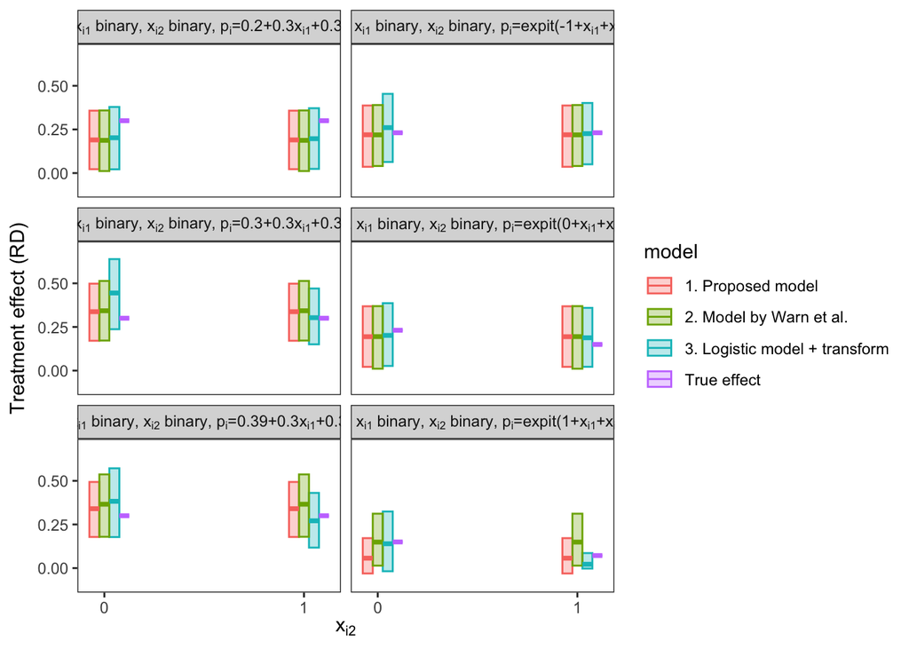

```r
rm(cure, trial.dat, true.beta, true.p, x, xpred)

# Plots
beta.plot$Scenario <- factor(beta.plot$Scenario,
                   levels=c("2x_bin_p=0.2+0.3x+0.3x",
                            "2x_bin_p=0.3+0.3x+0.3x",
                            "2x_bin_p=0.39+0.3x+0.3x",
                            "2x_bin_p=expit(-1+x+x)",
                            "2x_bin_p=expit(0+x+x)",
                            "2x_bin_p=expit(1+x+x)"),
                   labels=c(expression(paste("A. ", x[i*1], " binary, ", x[i*2], " binary, ", p[i],"=0.2+0.3",x[i*1],"+0.3",x[i*2],".")),
                            expression(paste("B. ", x[i*1], " binary, ", x[i*2], " binary, ", p[i],"=0.3+0.3",x[i*1],"+0.3",x[i*2],".")),
                            expression(paste("C. ", x[i*1], " binary, ", x[i*2], " binary, ", p[i],"=0.39+0.3",x[i*1],"+0.3",x[i*2],".")),
                            expression(paste("D. ", x[i*1], " binary, ", x[i*2], " binary, ", p[i],"=expit(-1+",x[i*1],"+",x[i*2],")")),
                            expression(paste("E. ", x[i*1], " binary, ", x[i*2], " binary, ", p[i],"=expit(0+",x[i*1],"+",x[i*2],")")),
                            expression(paste("F. ", x[i*1], " binary, ", x[i*2], " binary, ", p[i],"=expit(1+",x[i*1],"+",x[i*2],")"))
                            ))

plot1<- ggplot()+
      geom_crossbar(data=beta.plot,
                    aes(ymin = TE_low, ymax = TE_upp, fill=model,
                        x=xtilde, y=TE_pred, colour = model),
                    width=0.05, alpha=0.3)+
      xlab(expression(x[i*2]))+
      ylab(expression(paste("Treatment effect (RD)")))+
      theme_bw()+
      theme(panel.grid.minor = element_blank(),
               panel.grid.major = element_blank())+
      #xlim(c(-0.1, 1.1))+
      ylim(c(-0.1,0.7))+
      scale_x_continuous(breaks=c(0, 1))+
      facet_wrap(~Scenario, ncol = 2, dir = "v", labeller = label_parsed)

print(plot1)
```

```r
ggsave(plot = plot1, filename="2x_bin.pdf", height=6, width = 8)
```